# Exercise 13.8

Kári Hlynsson

April 2024

In this problem, we will simulate data from $m = 100$ fund managers.

```r
set.seed(1)
n <- 20
m <- 100
X <- matrix(rnorm(n * m), ncol = m)
```

These data represent each fund manager’s percentage returns for each of $n = 20$ months. We wish to test the null hypothesis that each fund manager’s percentage returns have population mean equal to zero. Notice that we simulated the data in such a way that each manager’s percentage returns do have population mean zero; in other words, all $m$ null hypotheses are true.

## Part (a)

Conduct a one-sample $t$-test for each fund manager, and plot a histogram of the $p$-values obtained.

```r
set.seed(1)
n <- 20
m <- 100
X <- matrix(rnorm(n * m), ncol = m)
```

Conduct the $t$-tests and store the values:

```r
pvals <- sapply(1:n, function(i) t.test(X[i, ])$p.value)
```

Histogram below:

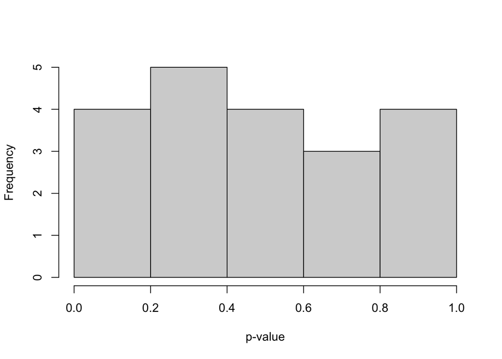

```r
hist(pvals, main = NA, xlab = "p-value")
```

## Part (b)

If we control Type I error for each null hypothesis at level $\alpha = 0.05$, then how many null hypotheses do we reject?

```r
sum(pvals < 0.05)
```

```
## [1] 1
```

Only one test is rejected.

## Part (c)

If we control the FWER at level 0.05, then how many null hypotheses do we reject?

```r
sum(p.adjust(pvals, method = "bonferroni") < 0.05)
```

```
## [1] 0
```

None of them.

```r
sum(p.adjust(pvals, method = "holm") < 0.05)
```

```
## [1] 0
```

Holm gives the same as Bonferroni. Very nice!

## Part (d)

If we control the FDR at level 0.05, then how many null hypotheses do we reject?

```r
sum(p.adjust(pvals, method = "fdr") < 0.05)
```

```
## [1] 0
```

None of them.

## Part (e)

Now suppose we “cherry-pick” the 10 fund managers who perform the best in our data. If we control the FWER for just these 10 fund managers at level 0.05, then how many null hypotheses do we reject? If we control the FDR for just these 10 fund managers at level 0.05, then how many null hypotheses do we reject?

```r
means <- apply(X, 1, mean)
best <- pvals[which(means %in% tail(sort(means), 10))]

sum(p.adjust(best, method = "bonferroni") < 0.05)
```

```
## [1] 0
```

Still, none of them are rejected.

## Part (f)

Explain why the analysis in (e) is misleading.

Cherry picking goes against the predicate that these are in fact representative of the random variable that is the test statistic. Here we have deliberately skewed that distribution by picking the best results, which is a gross misrepresentation of the true population.